# MS4S09 Assessment 1 Dataset Analysis

Ubong Effiong Etok 23122931

2026-02-08

## Loading Necessary Libraries

```r
libraries <- c(
  "tm", "tidytext", "ggplot2", "wordcloud", "syuzhet", "dplyr",
  "tibble", "textstem", "textdata", "tidyr", "Matrix",
  "topicmodels", "stringr", "reshape2", "LDAvis", "jsonlite",
  "e1071", "caTools", "caret", "slam"
)

#install.packages(libraries)

for (lib in libraries) {
  library(lib, character.only=TRUE)
}
```

## Load Dataset

```r
filepath <- "MS4S09 Assessment 1 Dataset.csv"
df <- as_tibble(read.csv(filepath, stringsAsFactors = FALSE))

print(summary(df))
```

```
##        X          Clothing.ID          Age          Title
##  Min.   :    0   Min.   :   0.0   Min.   :18.0   Length:23486
##  1st Qu.: 5871   1st Qu.: 861.0   1st Qu.:34.0   Class :character
##  Median :11742   Median : 936.0   Median :41.0   Mode  :character
##  Mean   :11742   Mean   : 918.1   Mean   :43.2
##  3rd Qu.:17614   3rd Qu.:1078.0   3rd Qu.:52.0
##  Max.   :23485   Max.   :1205.0   Max.   :99.0
##  Review.Text            Rating      Recommended.IND  Positive.Feedback.Count
##  Length:23486       Min.   :1.000   Min.   :0.0000   Min.   :  0.000
##  Class :character   1st Qu.:4.000   1st Qu.:1.0000   1st Qu.:  0.000
##  Mode  :character   Median :5.000   Median :1.0000   Median :  1.000
##                     Mean   :4.196   Mean   :0.8224   Mean   :  2.536
##                     3rd Qu.:5.000   3rd Qu.:1.0000   3rd Qu.:  3.000
##                     Max.   :5.000   Max.   :1.0000   Max.   :122.000
##  Division.Name      Department.Name     Class.Name
##  Length:23486       Length:23486       Length:23486
##  Class :character   Class :character   Class :character
##  Mode  :character   Mode  :character   Mode  :character
##
##
##
```

```r
print(head(df))
```

```
## # A tibble: 6 × 11
##       X Clothing.ID   Age Title               Review.Text Rating Recommended.IND
##   <int>       <int> <int> <chr>               <chr>        <int>           <int>
## 1     0         767    33 ""                  "Absolutel…      4               1
## 2     1        1080    34 ""                  "Love this…      5               1
## 3     2        1077    60 "Some major design… "I had suc…      3               0
## 4     3        1049    50 "My favorite buy!"  "I love, l…      5               1
## 5     4         847    47 "Flattering shirt"  "This shir…      5               1
## 6     5        1080    49 "Not for the very … "I love tr…      2               0
## # ℹ 4 more variables: Positive.Feedback.Count <int>, Division.Name <chr>,
## #   Department.Name <chr>, Class.Name <chr>
```

```r
print(colnames(df))
```

```
##  [1] "X"                       "Clothing.ID"
##  [3] "Age"                     "Title"
##  [5] "Review.Text"             "Rating"
##  [7] "Recommended.IND"         "Positive.Feedback.Count"
##  [9] "Division.Name"           "Department.Name"
## [11] "Class.Name"
```

## Data Selection and Sampling

```r
# This chunk cleans the dataset by removing missing and very short reviews, dropping unused columns, ensuring valid category labels, and adding a unique review identifier so text-level analysis can be aggregated back to the review level.

df <- df %>% filter(!is.na(Review.Text)) # Remove NA reviews first

df <- df %>%
  select(-c(1, 4, 7, 8)) %>% # This drops specific columns by position.
  filter(str_count(Review.Text, "\\S+") >= 20) # This Keeps only reviews with at least 20 words


df <- df[!is.na(df$Review.Text), ] # Removes all rows containing no reviews. it acts as a safety check to ensure no missing review text remains.


df <- df %>% filter(Division.Name != "") # Removes all rows containing blank Division.Name (where the field exists but is blank) values.


df$Review.ID <- 1:nrow(df) # Creates a unique numeric ID for each review. This ID is used later to: group tokens back into reviews, calculate sentiment per review, rejoin cleaned tokens with metadata, link sentiment, emotion, and topic outputs back to the original review
```

```r
# This chunk performs basic exploratory data analysis on the categorical variables in the dataset. It counts how many reviews belong to each Division, Department, Class

division_counts <- count(df, Division.Name, sort = TRUE) # Groups the dataset by Division.Name, Counts how many rows (reviews) fall into each division, Sorts results in descending order of frequency

department_counts <- count(df, Department.Name, sort = TRUE) # Groups the dataset by Department.Name, Counts how many rows (reviews) fall into each division, Sorts results in descending order of frequency

class_counts <- count(df, Class.Name, sort = TRUE) # Groups the dataset by Class.Name, Counts how many rows (reviews) fall into each division, Sorts results in descending order of frequency

print(head(division_counts))
```

```
## # A tibble: 3 × 2
##   Division.Name      n
##   <chr>          <int>
## 1 General        12310
## 2 General Petite  7215
## 3 Initmates       1262
```

```r
print(head(department_counts))
```

```
## # A tibble: 6 × 2
##   Department.Name     n
##   <chr>           <int>
## 1 Tops             9136
## 2 Dresses          5742
## 3 Bottoms          3392
## 4 Intimate         1470
## 5 Jackets           934
## 6 Trend             113
```

```r
print(head(class_counts))
```

```
## # A tibble: 6 × 2
##   Class.Name     n
##   <chr>      <int>
## 1 Dresses     5742
## 2 Knits       4130
## 3 Blouses     2770
## 4 Sweaters    1274
## 5 Pants       1253
## 6 Jeans       1018
```

```r
# This is a sanity check to visually confirm that the cleaned dataset has the expected structure before further analysis. It will help me catch errors early. It prints the first 6 rows of the cleaned dataset df to the output.

print(head(df))
```

```
## # A tibble: 6 × 8
##   Clothing.ID   Age Review.Text  Rating Division.Name Department.Name Class.Name
##         <int> <int> <chr>         <int> <chr>         <chr>           <chr>
## 1        1080    34 "Love this …      5 General       Dresses         Dresses
## 2        1077    60 "I had such…      3 General       Dresses         Dresses
## 3        1049    50 "I love, lo…      5 General Peti… Bottoms         Pants
## 4         847    47 "This shirt…      5 General       Tops            Blouses
## 5        1080    49 "I love tra…      2 General       Dresses         Dresses
## 6         858    39 "I aded thi…      5 General Peti… Tops            Knits
## # ℹ 1 more variable: Review.ID <int>
```

```r
# This chunk randomly selects a subset of 3,000 reviews from the cleaned dataset and stores it in sample_df. This sampled dataset is what I will use for all subsequent text mining, sentiment analysis, and topic modelling.

set.seed(1) # Ensures reproducibility
sample_df <- sample_n(df, 3000) # Random sampling minimises bias. It randomly selects 3000 rows from df. It ensures that every time this code is run, the same 3,000 rows are selected. Three thousand reviews are sufficient to capture dominant linguistic and sentiment patterns.
print(head(sample_df))
```

```
## # A tibble: 6 × 8
##   Clothing.ID   Age Review.Text  Rating Division.Name Department.Name Class.Name
##         <int> <int> <chr>         <int> <chr>         <chr>           <chr>
## 1        1083    64 "This dress…      5 General       Dresses         Dresses
## 2         828    62 "Love this …      5 General Peti… Tops            Blouses
## 3         933    30 "This remin…      4 General       Tops            Sweaters
## 4         829    39 "I am rarel…      5 General Peti… Tops            Blouses
## 5        1104    38 "Material i…      5 General       Dresses         Dresses
## 6         820    45 "Easy breez…      4 General       Tops            Blouses
## # ℹ 1 more variable: Review.ID <int>
```

## Tokenize Reviews

```r
# This chunk converts raw review text into tokens, which are the basic units used in text analysis. Single-word tokens (unigrams) and two-word sequences (bigrams) will be created which will be used for  frequency analysis, word clouds, sentiment analysis and phrase-level insights.
# Unigrams capture general themes, while bigrams capture context and phrases that single words cannot.

word_tokenized_data <- sample_df %>%
  unnest_tokens(output = word, input = "Review.Text", token = "words", to_lower = TRUE) # It takes a column containing text, breaks it into tokens, expands the dataset so that each token becomes one row Which will be essential for counting words, removing stopwords and joining sentiment dictionaries

bigram_tokenized_data <- sample_df %>%
  unnest_tokens(output = bigram, input = "Review.Text", token = "ngrams", n=2, to_lower = TRUE) # Bigram-level tokens are best for identifying common phrases, understanding how words are used together and extracting more semantic meaning
```

## Initial Exploratory Analysis

## Plot of top 10 words

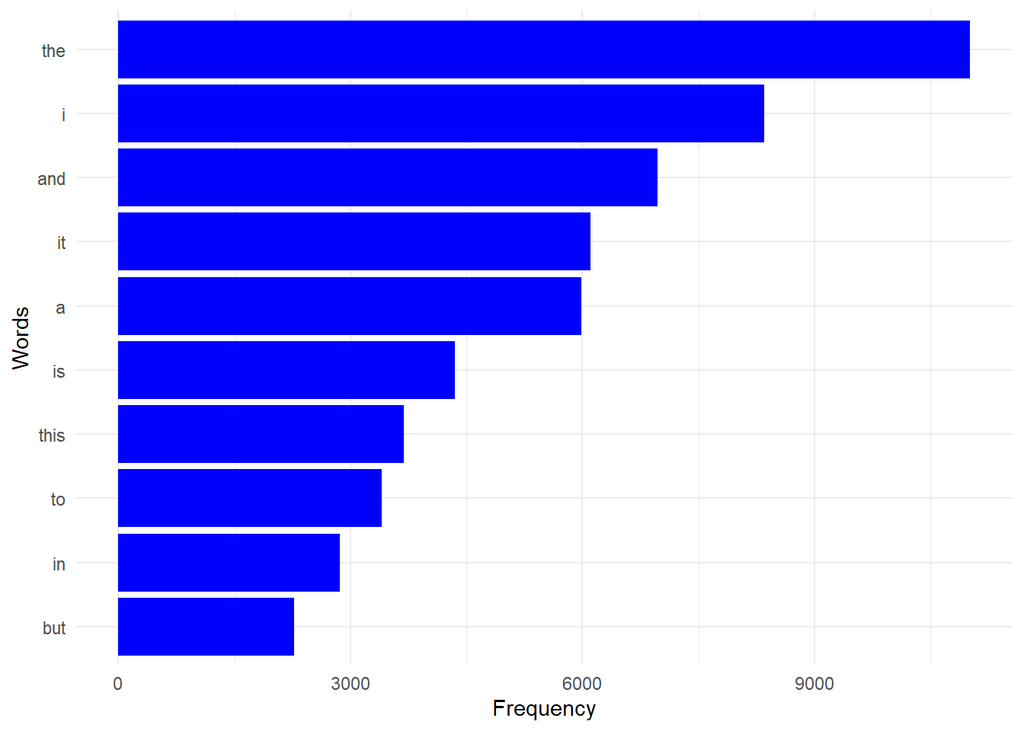

```r
# Counts the occurences of each word and sorts.
word_counts <- word_tokenized_data %>%
  count(word, sort = TRUE) # groups the tokenised data by word, counts how many times each word appears across all reviews and sorts the result in descending order of frequency

# Plots first 10 rows of word counts
ggplot(word_counts[1:10, ], aes(x = reorder(word, n), y = n)) +
  geom_col(fill = "blue") +
  labs(x = "Words", y = "Frequency") +
  coord_flip() +
  theme_minimal()
```

```r
# Repeats the earlier word count calculation
word_counts <- word_tokenized_data %>%
  count(word, sort = TRUE)

# This output shows that the plot is dominated by stopwords like: “the”, “and”, “i” and “it” proving that raw tokenisation alone is insufficient, preprocessing (stopword removal, cleaning) is necessary before interpretation
```

##### The initial plot of the top 10 words above is heavily dominated by stop words and offers little to no relevant information related to the context of the task (analysisng customer reviews of women’s clothing). This confirms that data cleaning and preprocessing must be performed to extract any meaningful information.

## Plot of top 10 bigrams

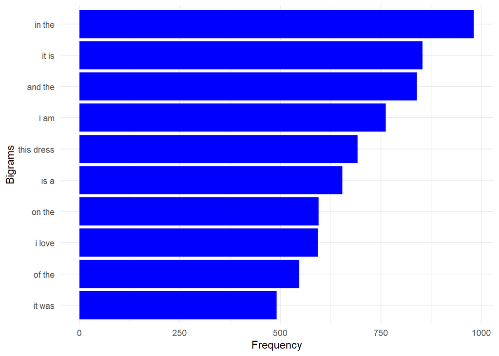

```r
bigram_counts <- bigram_tokenized_data %>%
  count(bigram, sort = TRUE) # Groups the tokenised bigram data by the bigram column, Counts how many times each two-word sequence appears across all reviews and Sorts the results in descending order of frequency

# Plots first 10 rows of bigram counts

ggplot(bigram_counts[1:10, ], aes(x = reorder(bigram, n), y = n)) + # selects the 10 most frequent bigrams, orders bigrams by frequency so bars appear sorted
  geom_col(fill = "blue") + # creates a bar chart with actual frequency values
  labs(x = "Bigrams", y = "Frequency") +
  coord_flip() + # flips axes so multi-word labels are readable
  theme_minimal() # applies a clean theme for readability
```

##### Similar to the initial plot of the top 10 words, this plot shows that raw bigrams are still dominated by function words, which motivates the need for preprocessing before extracting meaningful phrases as the bigram plot fails to provide any meaningful information that can help us understand customers reviews.

## Word Cloud

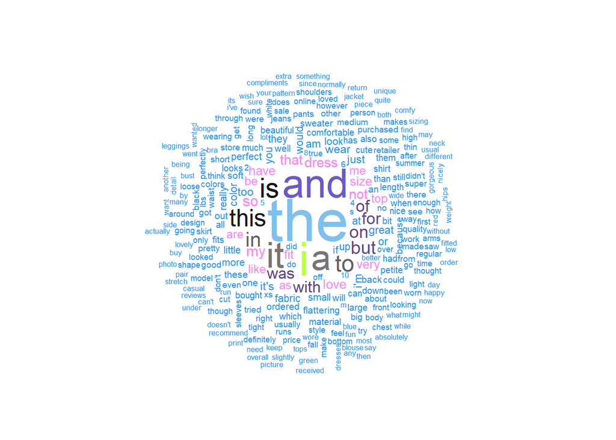

```r
set.seed(1)
wordcloud(words = word_counts$word, freq = word_counts$n, min.freq = 100,
          random.order=FALSE, random.color=FALSE,
          colors = sample(colors(), size = 12))
```

#### This word cloud shows the words that show up the most in the reviews. The bigger the word, the more often it shows up in the dataset. The fact that common terms like “the” and “and” are so common shows that the text hasn’t been thoroughly cleaned yet. This shows that stop-word removal and more preprocessing are needed before any meaningful interpretation can be done.

# TASK A: TEXT MINING

## Data Cleaning and Preprocessing

```r
# This chunk performs text preprocessing by removing stopwords, domain-specific noise, punctuation, and empty tokens, and by lemmatizing words to their base forms. This produces a clean token set suitable for sentiment analysis and topic modelling.

clean_tokens <- word_tokenized_data %>%
  anti_join(stop_words, by = "word") # keeps only words that do not appear in the stopword list. removes function words that carry little semantic meaning


# Removing words including highly generic domain words that are considered "noise" in the domain of clothing reviews for easy identification of trends
words_to_remove <- c("dress", "size", "wear", "color", "fabric", "length",
                     "material", "retailer", "shirt", "length", "pants", "jeans",
                     "top", "sweater", "skirt", "spin", "short", "buy")
clean_tokens <- clean_tokens %>%
  filter(!tolower(word) %in% tolower(words_to_remove)) # Converts both word, words_to_remove to lowercase and removes any token whose word appears in my custom list

clean_tokens$word <- gsub("[^a-zA-Z ]", "", clean_tokens$word) %>% # Removes punctuation, numbers, special characters, Keeps only letters and spaces
  trimws() %>% # Removes leading and trailing whitespace
  na_if("") %>% # Converts empty strings into NA
  lemmatize_words() # Converts words to their base dictionary form

clean_tokens <- na.omit(clean_tokens) # Removes any rows where word became NA
```

```r
# This chunk reconstructs each review as a cleaned string, re-attaches review-level metadata, prepares the data for clean bigram extraction

untokenized_data <- clean_tokens %>%
  group_by(Review.ID) %>% # Groups all word tokens that belong to the same review using the Review.ID that was earlier created

  summarize(clean_review = paste(word, collapse = " "), .groups = "drop") %>% # Takes all cleaned words in a review, joins them into one single string, separated by spaces. Removes grouping after summarisation to ensure the result is a regular dataframe, not grouped to prevent unexpected behaviour in later steps

  inner_join(sample_df %>% select(-Review.Text), by = "Review.ID") # This step adds back the non-text information and joins everything else like Age, Rating, Division, etc. back in

clean_bigrams <- untokenized_data %>%
  unnest_tokens(output = bigram, input = "clean_review", token = "ngrams", n=2, to_lower = TRUE) # Cleaned review are reconstructed from individual tokens and then bigrams are generated from the cleaned text, ensuring that phrase-level analysis reflects meaningful word sequences rather than raw, noisy text.
```

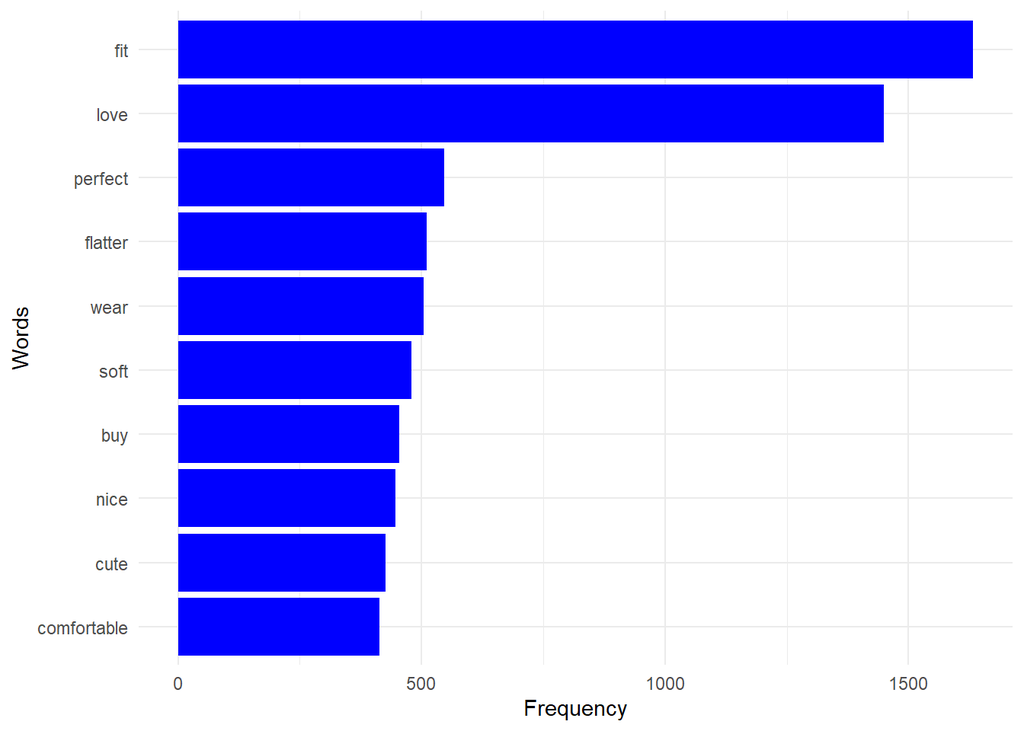

```r
# Counts the occurences of clean words and sorts.
word_counts <- clean_tokens %>%
  count(word, sort = TRUE) # Groups the cleaned token data by word, counts how often each cleaned word appears across all reviews, sorts results from most frequent to least frequent Key difference from earlier word count

top_words <- top_n(word_counts,10,n)$word # selects the 10 rows with the highest frequency and extracts just the word names

filtered_word_counts <- filter(word_counts, word %in% top_words) # Filters the full frequency table, keeps only rows corresponding to the top 10 words to reduce cluttering and prepares the data specifically for plotting

filtered_word_counts$word <- factor(filtered_word_counts$word, levels = rev(top_words)) # Converts word from a character vector into a factor, explicitly sets the factor levels to the top words in reverse order

# Plots first 10 rows of word counts
ggplot(filtered_word_counts, aes(x = reorder(word, n), y = n)) +
  geom_col(fill = "blue") +
  labs(x = "Words", y = "Frequency") +
  coord_flip() +
  theme_minimal() # keeps the plot clean
```

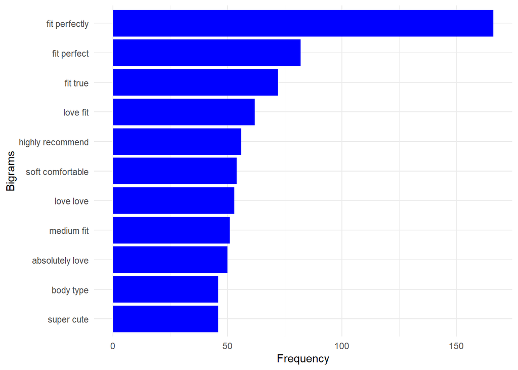

```r
# Counts the occurrences of clean bigrams and sorts.
bigram_counts <- clean_bigrams %>%
  count(bigram, sort = TRUE) # Groups the clean bigram dataset by bigram, counts how often each cleaned two-word phrase appears and sorts results from most frequent to least frequent

top_bigrams <- top_n(bigram_counts,10,n)$bigram # Selects the 10 most frequent bigrams based on count, extracts only the bigram text, stores them as a character vector

filtered_bigram_counts <- filter(bigram_counts, bigram %in% top_bigrams) # Filters the full bigram frequency table, keeps only rows corresponding to the top 10 bigrams and prepares a compact dataset for plotting

filtered_bigram_counts$bigram <- factor(filtered_bigram_counts$bigram, levels = rev(top_bigrams)) # Converts bigram into a factor, explicitly sets the plotting order and ensures bars appear ranked by frequency rather than alphabetically


# Plots first 10 rows of bigram counts
ggplot(filtered_bigram_counts, aes(x = reorder(bigram, n), y = n)) +
  geom_col(fill = "blue") +
  labs(x = "Bigrams", y = "Frequency") +
  coord_flip() +
  theme_minimal()
```

##### This plot further validates the observation that customers care more about how clothes fit on them than the overall looks/ aesthetics of the clothing.

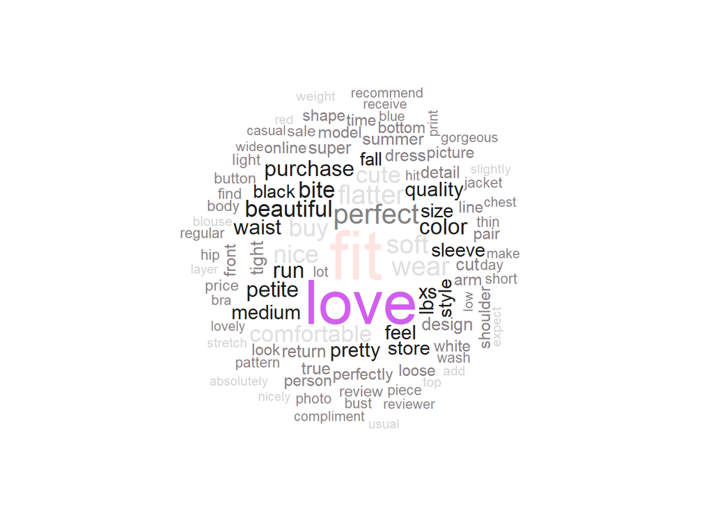

```r
# This chunk creates a word cloud from the cleaned word frequency data to provide a quick visual overview of dominant themes in customer reviews.
set.seed(2)
wordcloud(words = word_counts$word, freq = word_counts$n, min.freq = 25, # Supplies the list of words to display, Supplies frequency counts for each word. Words appearing fewer than 25 times are excluded to reduce clutter keeping the cloud readable and focuses on dominant themes
          max.words = 100, random.order=FALSE, random.color=FALSE, # Limits the word cloud to the 100 most frequent words preventing overcrowding. This Places most frequent words in the center, Less frequent words appear toward the edges and makes important words visually prominent
          colors = sample(colors(), size = 12))
```

##### Finally, we have the word cloud that also confirms that customers focus more on how clothes fit on them than on how they appear in the store.

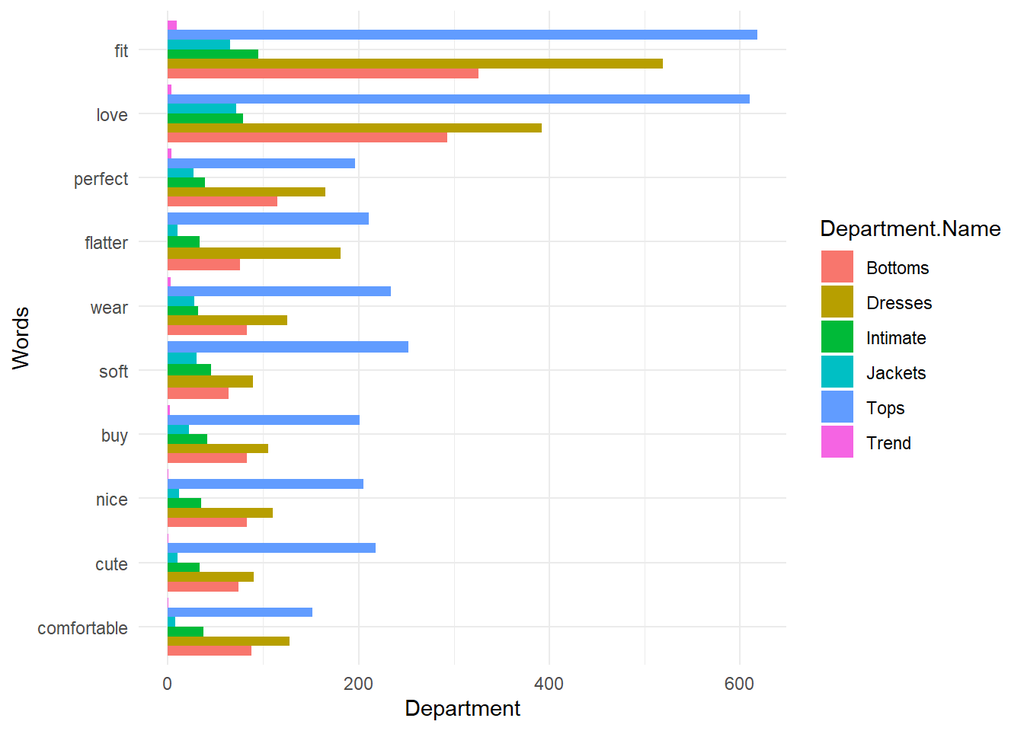

```r
# This chunk compares how frequently the most common words appear across departments, allowing me to identify differences in what customers emphasise for different product categories.

top_words <- top_n(word_counts,10,n)$word # Gets a vector of top 10 words

# Groups clean_tokens by department and counts the number of occurences of each word, and filters to only the top 10 words.
grouped_count <- group_by(clean_tokens, Department.Name) %>%
  count(word) %>%
  filter(word %in% top_words)

# Orders the top words according to overall frequency
grouped_count$word <- factor(grouped_count$word, levels = rev(top_words))

# Plots first 10 word groups
ggplot(data = grouped_count, aes(x = word, y = n, fill = Department.Name)) +
  geom_col(position = "dodge") +
  labs(x = "Words", y = "Department", fill = "Department.Name") +
  coord_flip() +
  theme_minimal()
```

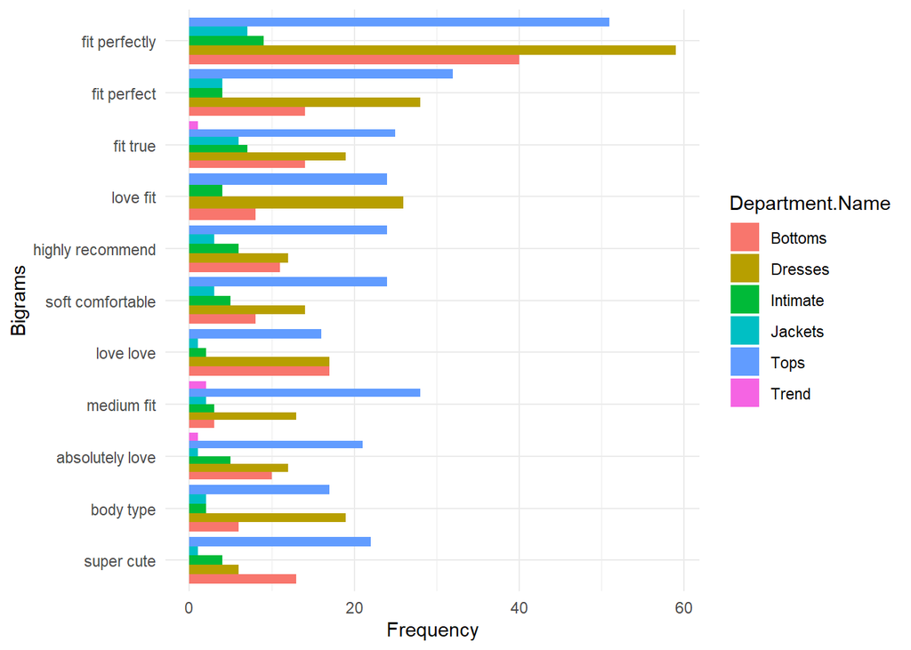

```r
# Gets a vector of top 10 bigrams
top_bigrams <- top_n(bigram_counts,10,n)$bigram # Uses the previously computed bigram_counts (from cleaned bigrams), selects the 10 most frequent bigrams overall and extracts only the bigram text into a character vector

grouped_count <- group_by(clean_bigrams, Department.Name) %>% # Groups the data by Department, ensures phrase counts are calculated within each department,

  count(bigram) %>% # Counts how many times each bigram appears per department, produces one row per (Department.Name, bigram) combination
  filter(bigram %in% top_bigrams) # Keeps only the top 10 bigrams overall, removes less frequent phrases to keep the plot readable

grouped_count$bigram <- factor(grouped_count$bigram, levels = rev(top_bigrams)) #  # Converts bigram into a factor, Sets factor levels to match the overall frequency ranking, Reverses the order so the most frequent phrases appear at the top

# Plots first 10 bigram groups
ggplot(data = grouped_count, aes(x = bigram, y = n, fill = Department.Name)) +
  geom_col(position = "dodge") +
  labs(x = "Bigrams", y = "Frequency", fill = "Department.Name") +
  coord_flip() +
  theme_minimal()
```

# Task B: SENTIMENT ANALYSIS

## Bing Lexicon

```r
# This chunk calculates a sentiment score for each review using the Bing sentiment dictionary and adds that score back to the dataset.

sentiment_data <- clean_tokens %>%
  inner_join(get_sentiments("bing"), by = "word") # Takes cleaned words, Keeps only words that have a sentiment label and adds a column saying whether each word is positive or negative

sentiment_score <- sentiment_data %>%
  group_by(Review.ID) %>%
  summarize(bing_sentiment = sum(sentiment == "positive") - sum(sentiment == "negative"),.groups = "drop")  # Groups words by review Counts (how many positive words are in the review, how many negative words are in the review) and subtracts negatives from positives

df_with_sentiment <- sample_df %>%
  inner_join(sentiment_score, by = "Review.ID") # The Bing lexicon to count positive and negative words in each review and creates a sentiment score for every review
```

```r
worst_review <- df_with_sentiment$Review.Text[which.min(df_with_sentiment$bing_sentiment)] # This line finds the review with the lowest Bing sentiment score and stores the text of that review in

best_review  <- df_with_sentiment$Review.Text[which.max(df_with_sentiment$bing_sentiment)] # This line finds the review with the highest Bing sentiment score and stores the text of that review in best_review.

print(worst_review)
```

```
## [1] "I've been buying stevie ankles for years from retailer and been very happy. the past two pairs i bought had a heavy chemical smell, which i imagine is some kind of starch/chemical to keep the denim stiff. with the first pair, after enough washes to get rid of the bad smell (4), they lost all…
```

```r
print(best_review)
```

```
## [1] "I saw this top online and fell in love with the overall casual look.\ni ordered all 3 colors, and they just arrived........love love love !!!\nthey are soft, comfortable and a have a very flattering casual fit.\nthe understated ruffled details add the special \"something\" that is so retaile…
```

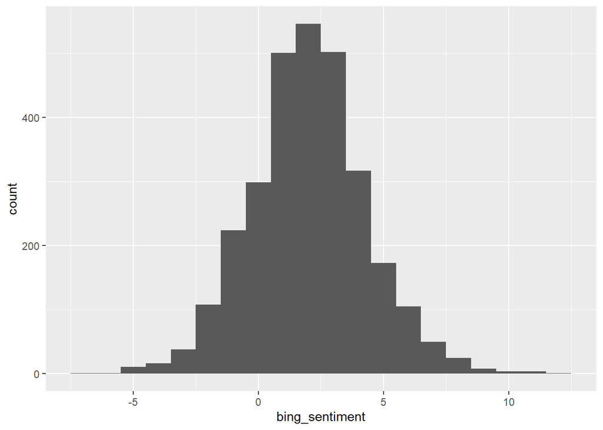

```r
# Histogram of sentiment scores
ggplot(df_with_sentiment, aes(x = bing_sentiment)) +
  geom_histogram(binwidth = 1)
```

#### The histogram plot exhibits a normal distribution with a slightly positive skew. This suggests that the more customers reporting to having a positive experience than a negative one.

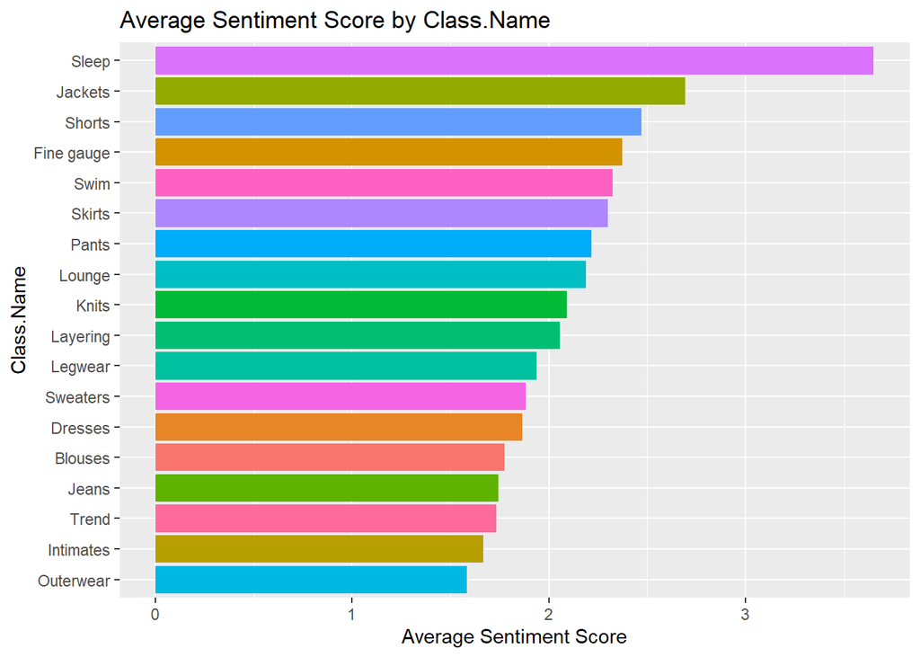

```r
# Average Sentiment by Class.Name
department_sentiment <- df_with_sentiment %>% # uses the dataset that already has sentiment scores
  group_by(Class.Name) %>% # groups reviews by product class
  summarize(Average_Bing_Sentimet = mean(bing_sentiment)) # computes the average sentiment score for each class

ggplot(department_sentiment, aes(x = reorder(Class.Name, Average_Bing_Sentimet), y = Average_Bing_Sentimet, fill = Class.Name)) +
  geom_bar(stat = "identity", show.legend = FALSE) +
  coord_flip() +
  labs(title = "Average Sentiment Score by Class.Name", x = "Class.Name", y = "Average Sentiment Score")
```

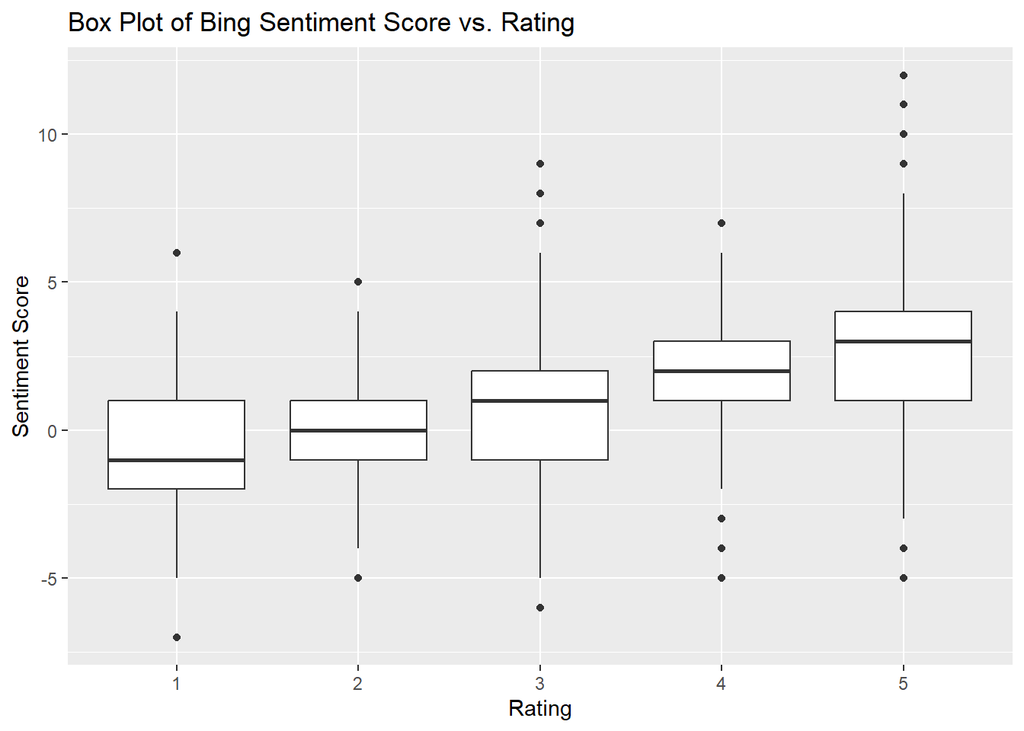

```r
# Box Plot of Sentiment against rating
ggplot(df_with_sentiment, aes(x = factor(Rating), y = bing_sentiment)) +
  geom_boxplot() +
  labs(title = "Box Plot of Bing Sentiment Score vs. Rating",
       x = "Rating",
       y = "Sentiment Score") # Uses the dataset that contains ratings and sentiment scores TO Convert Rating into a categorical variablE. Sets x-axis = rating (1–5) AND y-axis = sentiment score
```

#### The box plot shows that there is a link between customer evaluations and Bing sentiment scores that is good. Reviews that get higher ratings usually have higher median sentiment values. This suggests that textual sentiment aligns well with the numerical ratings provided by customers.

## NRC Lexicon

```r
# It assigns emotion categories (like joy, anger, trust, fear) to words using the NRC lexicon and counts how many of each emotion appear in every review.

emotion_data <- clean_tokens %>%
  inner_join(get_sentiments("nrc"),
    by = "word",
    relationship = "many-to-many") # Uses the NRC emotion dictionary, Keeps only words that have an emotion label, adds a column showing the emotion (e.g. joy, anger, trust), many-to-many because one word can belong to multiple emotions

emotion_count <- emotion_data %>%
  group_by(Review.ID) %>%
  count(sentiment) # Groups words by review, counts how many times each emotion appears in that review

wide_emotion_data <- emotion_count %>%
  pivot_wider(names_from = sentiment, values_from = n, values_fill = list(n = 0)) # Converts the data from long format to wide format, each emotion becomes its own column and missing emotions are filled with 0

df_with_sentiment = df_with_sentiment %>%
  inner_join(wide_emotion_data, by = "Review.ID") # Adds the emotion counts back to the main dataset
```

```r
# It prints the review text that has the highest count for each emotion category.

emotions <- c("joy", "positive", "trust", "anticipation", "surprise", "sadness", "negative", "anger", "disgust", "fear") # Creates a list of emotion names. These match the emotion columns created from the NRC analysis.

for (emotion in emotions) {
  print(paste("Review with highest score in", emotion)) # Prints a label to know which emotion is being examined
  review <- df_with_sentiment$Review.Text[which.max(df_with_sentiment[[emotion]])] #  # Selects the emotion column, finds the row with the highest value for that emotion and extracts the corresponding review text
  print(review) # Prints the review text with the strongest presence of that emotion
}
```

```
## [1] "Review with highest score in joy"
## [1] "I saw this top online and fell in love with the overall casual look.\ni ordered all 3 colors, and they just arrived........love love love !!!\nthey are soft, comfortable and a have a very flattering casual fit.\nthe understated ruffled details add the special \"something\" that is so retaile…
## [1] "Review with highest score in positive"
## [1] "I remember the first time i walked into an retailer store: like walking into a dream of all my favorite things. i've finally found a store whose products help me to express myself. as a writer, i love whimsical & out of the ordinary. i have found my honey hole. every time one of the pastel b…
## [1] "Review with highest score in trust"
## [1] "I... love... this dress. the fit is incredibly flattering (and i'm currently carrying more weight than my normal size). i selected a 6, which is about a size larger than normal, and it was a perfect fit. i tried on a larger size for measure, and the 6 provided a (perfect) fit and flare. i've…
## [1] "Review with highest score in anticipation"
## [1] "I remember the first time i walked into an retailer store: like walking into a dream of all my favorite things. i've finally found a store whose products help me to express myself. as a writer, i love whimsical & out of the ordinary. i have found my honey hole. every time one of the pastel b…
## [1] "Review with highest score in surprise"
## [1] "This dress is really lovely. if fits and flows in a very flattering way although it is a bit long (i'm really tall so that's a very nice feature for me :p) it actually feels more linen-y than i expected to which was surprising, (i probably didn't read the product description close enough) bu…
## [1] "Review with highest score in sadness"
## [1] "Just got this in a 2 petite (5'4\" 120lbs 34b) and it fits perfectly. the length is right at the bottom of the knee. it is fitted tight at the waist and the belt is even more beautiful in person. this dress has some weight and the quality seems excellent. there is a scalloped nude lining tha…
## [1] "Review with highest score in negative"
## [1] "When i saw this top online, i thought i'd love it and immediately ordered it in both colors.  they arrived today and i am soooo disappointed.  i have never seen such drab colors.  the blue is a muddy grayish hue (like an overcast day) and the pink is a dusty shade of peach.  yuck.  and i was…
## [1] "Review with highest score in anger"
## [1] "I've been buying stevie ankles for years from retailer and been very happy. the past two pairs i bought had a heavy chemical smell, which i imagine is some kind of starch/chemical to keep the denim stiff. with the first pair, after enough washes to get rid of the bad smell (4), they lost all…
## [1] "Review with highest score in disgust"
## [1] "I've been buying stevie ankles for years from retailer and been very happy. the past two pairs i bought had a heavy chemical smell, which i imagine is some kind of starch/chemical to keep the denim stiff. with the first pair, after enough washes to get rid of the bad smell (4), they lost all…
## [1] "Review with highest score in fear"
## [1] "I love this tee but there is a lot of swing/ fabric so it can tend to make you look wide. also, i have a short torso to begin with but this tee is on the short side. i'm still undecided on whether i'm going to keep it b/c it's rayon/ poly and it's hand wash only. and i'm worried that one was…
```

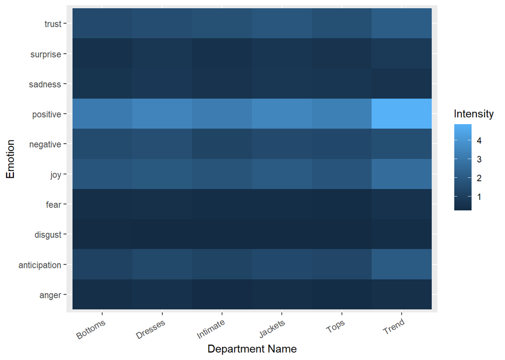

```r
# It creates a heatmap showing the average intensity of each emotion across product departments.

long_df <- df_with_sentiment %>%
  pivot_longer(
    cols = c("joy", "positive", "trust", "anticipation", "surprise", "sadness", "negative", "anger", "disgust", "fear"),
    names_to = "Emotion",
    values_to = "Intensity"
  ) # Converts emotion columns from wide format to long format, each row now represents one review, one emotion and its intensity value which is required for grouped analysis and plotting.

emotion_scores <- long_df %>%
  group_by(Department.Name, Emotion) %>%
  summarize(avg_intensity = mean(Intensity), .groups = "drop") # Groups data by department and emotion and calculates the average emotion intensity for each department

ggplot(emotion_scores, aes(x = Department.Name, y = Emotion, fill = avg_intensity)) +
  geom_tile() +  # Creates the heatmap tiles
  labs(x = "Department Name", y = "Emotion", fill = "Intensity") +
  theme(axis.text.x = element_text(angle = 30, hjust = 1)) # Rotates text to 30 degrees and hjust=1 aligns text to the right
```

#### The heat map indicates that there is a strong intensity of positive emotions such as trust, joy, anticipation. This confirms that the majority of reviews were from satisfied customers.

# Task C: TOPIC MODELLING

## Convert data to a clean Term Document Matrix (TDM)

```r
# It prepares the review text for topic modelling by cleaning it and converting it into a term–document matrix.

topic_df <- sample_df %>%
  filter(str_count(Review.Text, "\\S+") >= 50) # Keeps only reviews with at least 50 words because longer reviews work better for topic modelling as it reduces noise from very short texts

corpus <- VCorpus(VectorSource(topic_df$Review.Text)) # Converts the review text into a text corpus

corpus <- tm_map(corpus, content_transformer(tolower)) # Converts all text to lowercase

corpus <- tm_map(corpus, content_transformer(function(x) gsub("[^a-zA-Z ]", "", x))) # Removes punctuation, numbers, and special characters, Keeps only letters and spaces

corpus <- tm_map(corpus, removeWords, stopwords("en")) # Removes common English stopwords like "the", "and", "is", etc., reduces noise in topic modelling

corpus <- tm_map(corpus, stemDocument) # Applies stemming, reduces words to their root form (e.g. fitting → fit) and helps group similar words together

tdm <- TermDocumentMatrix(corpus, control = list(wordLengths = c(3, 15))) # # Convert to a term document matrix and Keeps words between 3 and 15 characters long

tdm_matrix <- as.matrix(tdm) # Converts the term–document matrix into a standard matrix which makes it easier to process later
```

## Term Selection

```r
# Calculates how often each word appears in the corpus, shows the top words, and visualises the overall word-frequency distribution.

term_frequencies <- rowSums(tdm_matrix) # Adds up each row of the term–document matrix

term_frequency_df <- data.frame(term = names(term_frequencies), frequency = term_frequencies) # Converts the frequency results into a dataframe with each row = one word and its total frequency

top_terms <- term_frequency_df %>%
  arrange(desc(frequency)) %>%
  head(10) # Sort the data frame by frequency in descending order and select the top 10

print(top_terms) # Displays the top 10 words and their frequencies which is Used as a quick check of dominant terms
```

```
##        term frequency
## dress dress      1360
## fit     fit      1220
## size   size      1201
## love   love      1098
## look   look      1027
## like   like       853
## top     top       851
## wear   wear       845
## color color       740
## just   just       619
```

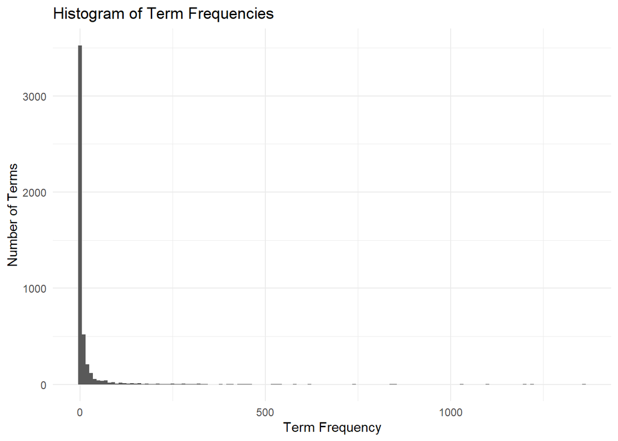

```r
ggplot(term_frequency_df, aes(x = frequency)) +
  geom_histogram(binwidth = 10) +
  labs(title = "Histogram of Term Frequencies",
       x = "Term Frequency",
       y = "Number of Terms") +
  theme_minimal() # histogram to show how many words occur rarely vs frequently
```

#### This histogram shows the distribution of term frequencies in the corpus. Most words occur very rarely, while a small number of words occur very frequently, resulting in a highly right-skewed distribution. This pattern is typical of text data and justifies removing extremely rare and extremely frequent terms before topic modelling to improve model quality.

```r
frequent_terms <- findFreqTerms(tdm, lowfreq = 0.10 * ncol(tdm_matrix)) # Find terms that appear in more than 10% of documents

rare_terms <- findFreqTerms(tdm, highfreq = 0.005 * ncol(tdm_matrix)) # Find terms that appear in less than 0.5% of documents

print("Frequent Terms")
```

```
## [1] "Frequent Terms"
```

```r
print(frequent_terms)
```

```
##  [1] "also"    "back"    "beauti"  "bit"     "black"   "bought"  "can"
##  [8] "color"   "comfort" "cute"    "design"  "dont"    "dress"   "even"
## [15] "fabric"  "feel"    "fit"     "flatter" "get"     "good"    "got"
## [22] "great"   "jean"    "just"    "larg"    "lbs"     "length"  "like"
## [29] "littl"   "long"    "look"    "love"    "made"    "make"    "materi"
## [36] "medium"  "much"    "nice"    "one"     "order"   "pant"    "perfect"
## [43] "petit"   "pretti"  "purchas" "qualiti" "realli"  "retail"  "review"
## [50] "right"   "run"     "see"     "shirt"   "short"   "size"    "skirt"
## [57] "sleev"   "small"   "soft"    "still"   "store"   "style"   "sweater"
## [64] "think"   "tight"   "top"     "tri"     "usual"   "waist"   "want"
## [71] "way"     "wear"    "well"    "will"    "work"
```

```r
print("First 20 Infrequent Terms")
```

```
## [1] "First 20 Infrequent Terms"
```

```r
print(rare_terms[1:20])
```

```
##  [1] "abil"       "abject"     "abou"       "absorb"     "abstract"
##  [6] "abt"        "accent"     "accentu"    "accept"     "acceptabl"
## [11] "access"     "accessor"   "accessori"  "accid"      "accident"
## [16] "accomod"    "accomplish" "accord"     "account"    "accur"
```

```r
# Edit list of frequent words to keep useful ones
to_keep <- c("christian", "recip")
to_remove <- frequent_terms[!frequent_terms %in% to_keep]

# Removes overly frequent words and overly rare words
filtered_tdm_matrix <- tdm_matrix[!rownames(tdm_matrix) %in% to_remove, ]
filtered_tdm_matrix <- filtered_tdm_matrix[!rownames(filtered_tdm_matrix) %in% rare_terms, ]

column_sums <- colSums(filtered_tdm_matrix) # Calculating column sums to Check for documents that now contain no remaining words

zero_columns <- which(column_sums == 0) # Identify columns that are all zeros

# # Removes empty documents to prevent errors in topic modelling.  If no columns are all zeros, just use the original matrix
if(length(zero_columns) > 0) {
  filtered_tdm_matrix <- filtered_tdm_matrix[, -zero_columns]
} else {

  print("No zero columns in TDM matrix")
}
```

```
## [1] "No zero columns in TDM matrix"
```

```r
# This chunk recalculates word frequencies after filtering and visualizes the updated frequency distribution.

term_frequencies <- rowSums(filtered_tdm_matrix) # Adds up how often each remaining word appears using the filtered term–document matrix

# Converts word frequencies into a dataframe. Each row = one word and its total frequency
term_frequency_df <- data.frame(
  term = names(term_frequencies),
  frequency = term_frequencies
)

# Sorts words by frequency by Selecting the top 10 most frequent remaining words
top_terms <- term_frequency_df %>%
  arrange(desc(frequency)) %>%
  head(10)

print(top_terms) # Display the top 10 most frequent terms after filtering
```

```
##              term frequency
## didnt       didnt       190
## arm           arm       188
## onlin       onlin       184
## big           big       182
## model       model       182
## cut           cut       181
## front       front       179
## return     return       176
## howev       howev       174
## shoulder shoulder       171
```

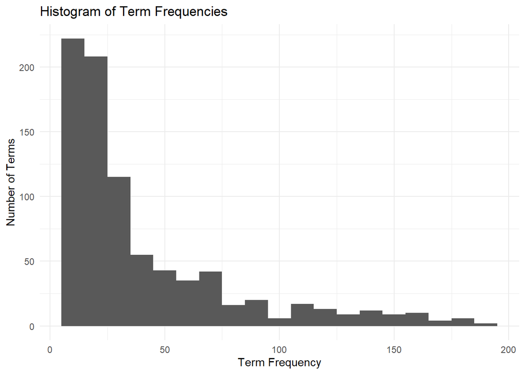

```r
# Visualize the distribution of term frequencies
ggplot(term_frequency_df, aes(x = frequency)) +
  geom_histogram(binwidth = 10) +
  labs(
    title = "Histogram of Term Frequencies",
    x = "Term Frequency",
    y = "Number of Terms") +
  theme_minimal()
```

#### This histogram shows the distribution of word frequencies after filtering. Most terms still occur at low frequencies, while a smaller number of terms occur more frequently, indicating a right-skewed distribution. The reduction in extreme values shows that filtering has successfully removed very rare and overly common terms, making the data more suitable for topic modelling.

```r
# Manually remove remaining generic terms

to_remove <- c("help", "author", "present", "cover", "work") # Creates a list of generic words as these words are not useful for identifying topics

filtered_tdm_matrix <- filtered_tdm_matrix[!rownames(filtered_tdm_matrix) %in% to_remove, ] # Removes those generic words from the term–document matrix , further cleans the vocabulary

term_frequencies <- rowSums(filtered_tdm_matrix) # Recalculates how often each remaining word appears

# Converting frequencies into a dataframe
term_frequency_df <- data.frame(
  term = names(term_frequencies),
  frequency = term_frequencies
)

# Sort terms by frequency and extract the top 10
top_terms <- term_frequency_df %>%
  arrange(desc(frequency)) %>%
  head(10)

# Display the top 10 most frequent remaining terms
print(top_terms)
```

```
##              term frequency
## didnt       didnt       190
## arm           arm       188
## onlin       onlin       184
## big           big       182
## model       model       182
## cut           cut       181
## front       front       179
## return     return       176
## howev       howev       174
## shoulder shoulder       171
```

## Create LDA Model

```r
# It prepares the data in the correct format and fits an LDA topic model with 3 topics.

dtm <- t(filtered_tdm_matrix) # Transposes the matrix, Changes it from term–document to document–term as LDA requires documents as rows

dtm_stm <- slam::as.simple_triplet_matrix(dtm) # Converts the matrix into a sparse format. This saves memory and is required by the topicmodels package

lda_model <- LDA(dtm_stm, k = 3, control = list(seed = 1)) # Fits an LDA topic model, asks the model to find 3 topics and make results reproducible
```

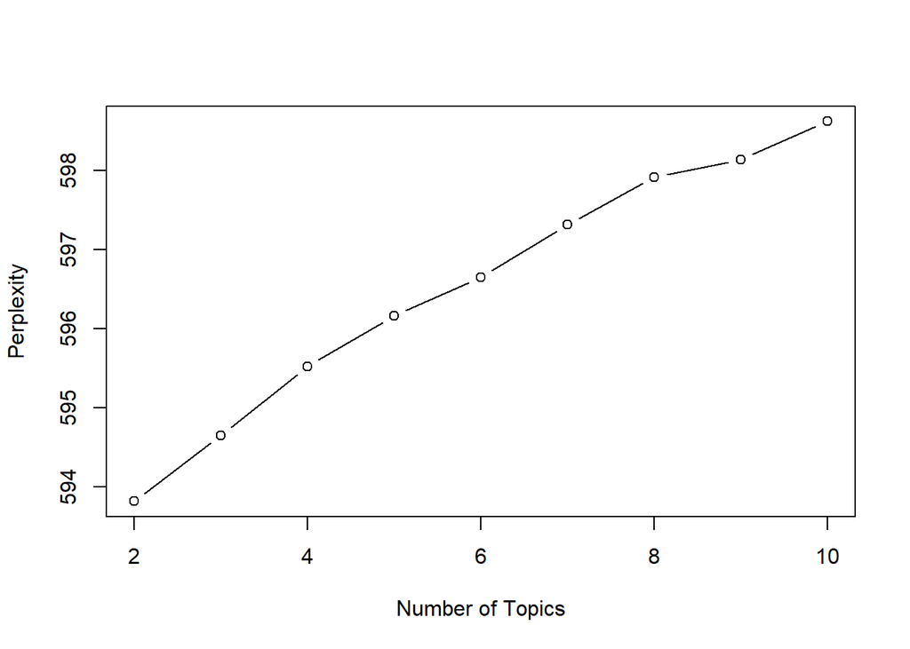

```r
# It tests different numbers of topics and uses perplexity to help decide how many topics to use in the LDA model.

range_k <- seq(2, 10, by = 1) # Creates a list of topic numbers to test Here, it tests 2 to 10 topics
perplexities <- sapply(range_k, function(k) {  # Loops over each value of k and Runs the same process for every topic number
  model <- LDA(dtm_stm, k = k, control = list(seed = 1))  # Fits an LDA model using k topics by using the same seed so results are comparable
  perplexity(model) # Calculates the perplexity score for that model as Perplexity measures how well the model fits the data
})

# Plotting perplexities
plot(range_k, perplexities, type = "b", xlab = "Number of Topics", ylab = "Perplexity")
```

#### The perplexity plot indicates that two topics minimise perplexity and are therefore optimal from a statistical standpoint.

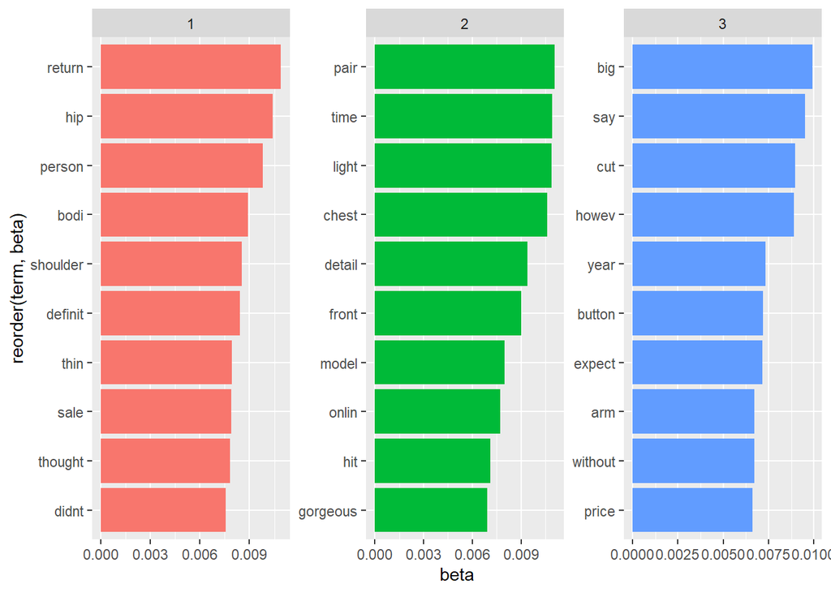

```r
# It extracts the most important words for each topic and visualizes them using bar charts.

topics <- tidy(lda_model, matrix = "beta") # Converts the LDA model into a tidy dataframe with a probability of each word belonging to each topic

# Groups words by topic, Selects the top 10 most important words per topic, sorts them by importance within each topic
top_terms <- topics %>%
  group_by(topic) %>%
  top_n(10, beta) %>%
  ungroup() %>%
  arrange(topic, -beta)

# Visualise the top terms for each topic in ggplot
top_terms %>%
  ggplot(aes(x = reorder(term, beta), y = beta, fill = factor(topic))) +
  geom_col(show.legend = FALSE) +
  facet_wrap(~ topic, scales = "free") +
  coord_flip()
```

#### Topic 1: The use of words like “return,” “hip,” “body,” and “shoulder” shows that this topic is about consumer problems with fit and comfort, which are often linked to returns and displeasure.

#### Topic 2: Words like “light,” “detail,” “front,” “model,” and “online” are used to talk about this topic. These words illustrate that it has to do with how things look, how they are created, and how they seem when you buy them online.

#### Topic 3: The words “big,” “cut,” “button,” “arm,” and “expect” demonstrate that this issue is about how customers communicate about sizing, how garments are created, and whether items live up to their expectations.

```r
# It creates an interactive visualisation of the LDA topics to help interpret how topics and words relate to each other.

set.seed(1) # Set seed for reproducibility of the LDA model

lda_model <- LDA(dtm_stm, k = 3, control = list(seed = 1)) # Fit LDA model with 3 topics on the document-term matrix

# Preparing LDA outputs (topics and terms) for interactive visualization
lda_vis_data <- createJSON( # Prepares the LDA results in the format required by LDAvis. This converts model outputs into JSON data
  phi = posterior(lda_model)$terms, # Gives topic–word probabilities. Shows which words are important for each topic
  theta = posterior(lda_model)$topics, # Gives document–topic probabilities. hows how strongly each review belongs to each topic
  doc.length = rowSums(as.matrix(dtm_stm)), # Calculates the number of words in each document
  vocab = colnames(as.matrix(dtm_stm)), # Supplies the list of words used in the model
  term.frequency = colSums(as.matrix(dtm_stm)) # Calculates how often each word appears overall
)
serVis(lda_vis_data) # Launch interactive LDA visualization allowing exploration of topics and keywords in a browser-style view
```

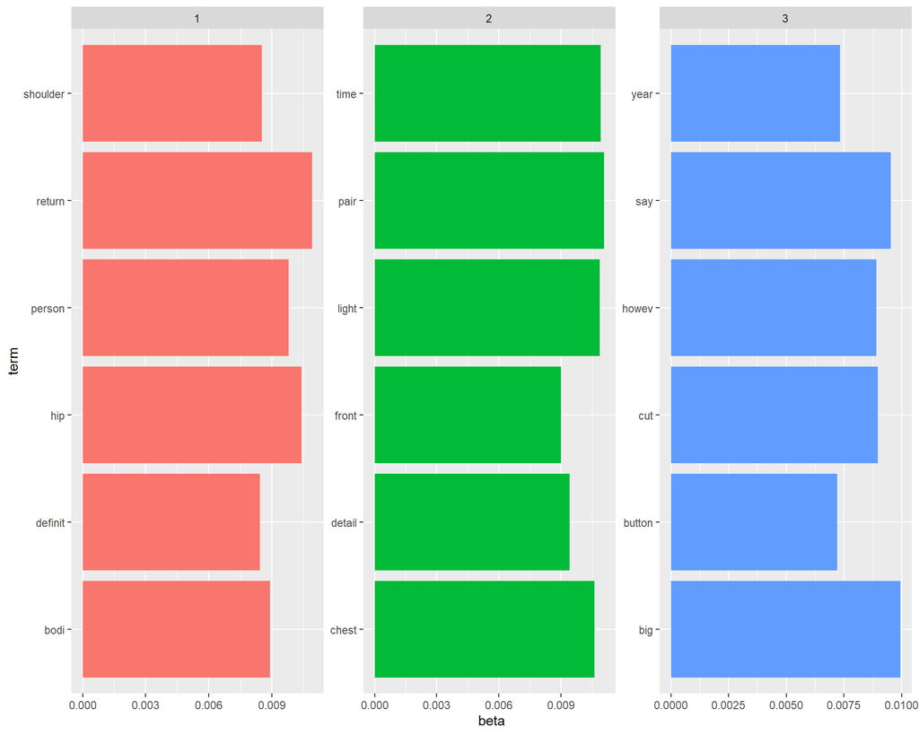

```r
# It visualizes the key words for each topic, saves the plot, and extracts how strongly each review belongs to each topic.

topics <- tidy(lda_model, matrix = "beta") # Converts the LDA model into a tidy format with the probability of a word belonging to a topic

# Groups words by topic, Selects the top 6 most important words for each topic and Sorts them by importance
top_terms <- topics %>%
  group_by(topic) %>%
  top_n(6, beta) %>%
  ungroup() %>%
  arrange(topic, -beta)

# Creating bar plot of top terms for each topic
p <- top_terms %>%
  ggplot(aes(term, beta, fill = factor(topic))) +
  geom_col(show.legend = FALSE) +
  facet_wrap(~ topic, scales = "free") +
  coord_flip()

print(p) # Print plot
```

```r
ggsave("plot.png", plot = p, width = 10, height = 8) # Save plot

documents <- tidy(lda_model, matrix = "gamma") # Getting the topic proportions for each review showing how much each topic contributes to each document

print(head(documents))
```

```
## # A tibble: 6 × 3
##   document topic gamma
##   <chr>    <int> <dbl>
## 1 1            1 0.335
## 2 2            1 0.336
## 3 3            1 0.337
## 4 4            1 0.338
## 5 5            1 0.338
## 6 6            1 0.332
```

# Task D - Further Exploration

```r
# It recalculates a Bing sentiment score for each review and creates a binary variable indicating whether the product was recommended.

# Uses the review ID and review text only. Keeps only the columns needed for sentiment analysis
bing_sentiment <- sample_df %>%
  select(Review.ID, Review.Text) %>%

  # Breaks each review into individual words. Creates one row per word
  unnest_tokens(word, Review.Text) %>%

  # Keeps only words that have positive or negative sentiment and adds a sentiment label to each word
  inner_join(get_sentiments("bing"), by = "word") %>%

  # Groups words back into their original reviews
  group_by(Review.ID) %>%

  # Adds +1 for each positive word, −1 for each negative word and produces one sentiment score per review
  summarise(bing_sentiment = sum(ifelse(sentiment == "positive", 1, -1)), .groups = "drop")

# Creates a new variable called recommendation. If rating is 4 or 5 choose recommended (1) Otherwise not recommended (0)
sample_df <- sample_df %>%
  mutate(recommendation = ifelse(Rating >= 4, 1, 0))
```

```r
# It builds a logistic regression model to predict whether a product is recommended using sentiment score and age.

# Merges sentiment scores into the review dataset and ensures each review has a sentiment value
model_data <- sample_df %>%
  inner_join(bing_sentiment, by = "Review.ID") %>%

  # Keeps only variables needed for modelling: recommendation (outcome), sentiment score and age
  select(recommendation, bing_sentiment, Age) %>%

  # Converts recommendation into a categorical variable required for logistic regression
  mutate(recommendation = as.factor(recommendation))

# Fits a logistic regression model, Predicts recommendation using sentiment score and age
linear_model <- glm(recommendation ~ bing_sentiment + Age,
                 data = model_data,
                 family = "binomial")

summary(linear_model) # Displays model coefficients and significance by showing how sentiment and age affect recommendation
```

```
##
## Call:
## glm(formula = recommendation ~ bing_sentiment + Age, family = "binomial",
##     data = model_data)
##
## Coefficients:
##                 Estimate Std. Error z value Pr(>|z|)
## (Intercept)    -0.046388   0.179041  -0.259    0.796
## bing_sentiment  0.381656   0.021622  17.651   <2e-16 ***
## Age             0.002868   0.003884   0.738    0.460
## ---
## Signif. codes:  0 '***' 0.001 '**' 0.01 '*' 0.05 '.' 0.1 ' ' 1
##
## (Dispersion parameter for binomial family taken to be 1)
##
##     Null deviance: 3261.9  on 2990  degrees of freedom
## Residual deviance: 2863.0  on 2988  degrees of freedom
## AIC: 2869
##
## Number of Fisher Scoring iterations: 5
```

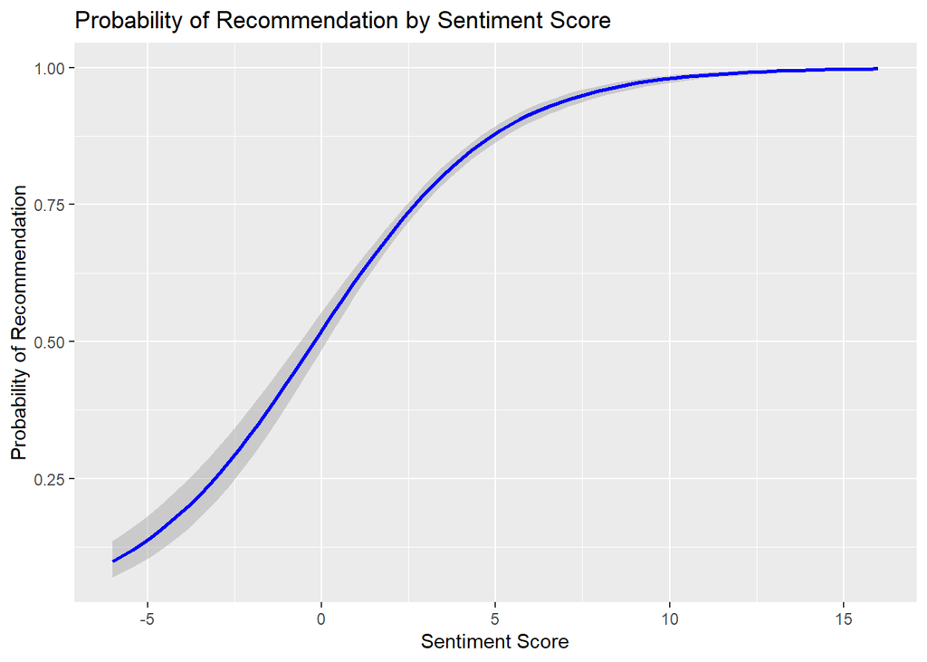

```r
# Plot the probability of recommending a product based on sentiment
ggplot(model_data, aes(x = bing_sentiment, y = as.numeric(recommendation) - 1)) +
  geom_smooth(
    method = "glm",
    method.args = list(family = "binomial"),
    color = "blue"
  ) +
  labs(
    title = "Probability of Recommendation by Sentiment Score",
    x = "Sentiment Score",
    y = "Probability of Recommendation"
  )
```

#### This plot visualises the predicted probability of recommending a product as sentiment score increases. The S-shaped curve shows that reviews with more positive sentiment have a much higher likelihood of recommendation, while very negative sentiment corresponds to low recommendation probability.

# References

[1] Mohammad, S.M. and Turney, P.D. (2012). CROWDSOURCING A WORD-EMOTION ASSOCIATION LEXICON. Computational Intelligence, 29(3), pp.436–465. doi:https://doi.org/10.1111/j.1467-8640.2012.00460.x. [2] GeeksforGeeks (2023). Generalized Linear Models Using R. [online] GeeksforGeeks. Available at: https://www.geeksforgeeks.org/r-language/generalized-linear-models-using-r/. [3] Blei, D.M., Ng, A.Y. and Jordan, M.I. (2003). Latent Dirichlet Allocation. Journal of Machine Learning Research, 3, pp.993–1022. [4] Sievert, C. and Shirley, K. (2014). LDAvis: A method for visualizing and interpreting topics. Proceedings of the Workshop on Interactive Language Learning, Visualization, and Interfaces, pp.63–70.